# ROI study 2023

# 4 Outcome models

## 4.1 Spring effect on gross medical spending

Below are the results of the total cost of care study across the entire population and the matched group only.

```r
# Let's recode customer so the intercept reflects the average across participants
cust_recode <- df_matched %>%
  group_by(customer_name) %>%
  summarize(cust_row_count = n()) %>%
  ungroup() %>%
  mutate(cust_prop = cust_row_count/sum(cust_row_count)) %>%
  select(customer_name, cust_prop) %>%
  pivot_wider(names_from = customer_name, values_from = cust_prop)

df_matched <- df_matched %>%
  mutate(
    Hearst = ifelse(customer_name == "Hearst", 1, 0),
    Pepsi = ifelse(customer_name == "Pepsi", 1, 0),
    Tegna = ifelse(customer_name == "Tegna", 1, 0),
    Wellstar = ifelse(customer_name == "Wellstar", 1, 0),
    DocuSign = ifelse(customer_name == "DocuSign", 1, 0)
  )

df_analyze_all <- df_analyze_all %>%
  mutate(
    Hearst = ifelse(customer_name == "Hearst", 1, 0),
    Pepsi = ifelse(customer_name == "Pepsi", 1, 0),
    Tegna = ifelse(customer_name == "Tegna", 1, 0),
    Wellstar = ifelse(customer_name == "Wellstar", 1, 0),
    DocuSign = ifelse(customer_name == "DocuSign", 1, 0)
  )


## Gross
m1_gross_no_match <- lmer(med_pmpm_trunc ~ 1 + spring_dummy + spring_dummy*phase + Hearst + Pepsi + Tegna + Wellstar +
             (1 | carrier_member_id),
           data = filter(df_analyze_all, index_date >= spring_start_date))

m1_gross_yes_match <- lmer(med_pmpm_trunc ~ 1 + spring_dummy + spring_dummy*phase + Hearst + Pepsi + Tegna + Wellstar +
             (1 | carrier_member_id) +
             (1 | subclass_nn),
           weights = weights_nn,
           data = df_matched)

m1_gross_exclusions <- lmer(med_pmpm_trunc ~ 1 + spring_dummy + spring_dummy*phase + Hearst + Pepsi + Tegna + Wellstar +
             (1 | carrier_member_id) +
             (1 | subclass_nn),
           weights = weights_nn,
           data = filter(df_matched, excl_pregnancy != "yes"))

tab_model(m1_gross_no_match, m1_gross_yes_match, m1_gross_exclusions,
          show.ci=F,
          show.se=T,
          pred.labels = c("Baseline PMPM", "Baseline difference (Spring - Control)", "Control pre-post change", "Hearst", "Pepsi", "Tegna", "Wellstar", "Diff-in-diff (Spring change - Control change)"),
          dv.labels = c("Umatched", "Matched", "Exclude pregnancy"),
          title = "Spring effect on gross medical spending")
```

Spring effect on gross medical spending

|  | Umatched |  |  | Matched |  |  | Exclude pregnancy |  |  |
| --- | --- | --- | --- | --- | --- | --- | --- | --- | --- |
| Predictors | Estimates | std. Error | p | Estimates | std. Error | p | Estimates | std. Error | p |
| Baseline PMPM | 415.03 | 55.16 | **<0.001** | 354.12 | 53.27 | **<0.001** | 314.22 | 53.89 | **<0.001** |
| Baseline difference (Spring - Control) | -74.85 | 33.21 | **0.024** | 24.45 | 23.44 | 0.297 | 13.70 | 23.96 | 0.567 |
| Control pre-post change | 377.05 | 9.37 | **<0.001** | 332.03 | 16.86 | **<0.001** | 338.19 | 16.72 | **<0.001** |
| Hearst | 66.76 | 65.50 | 0.308 | -23.47 | 66.25 | 0.723 | -9.11 | 66.77 | 0.891 |
| Pepsi | 79.55 | 55.87 | 0.155 | 107.70 | 56.34 | 0.056 | 118.95 | 56.98 | **0.037** |
| Tegna | 4.97 | 69.69 | 0.943 | -99.42 | 67.79 | 0.143 | -83.48 | 68.30 | 0.222 |
| Wellstar | 383.17 | 60.02 | **<0.001** | 224.24 | 59.96 | **<0.001** | 236.61 | 60.66 | **<0.001** |
| Diff-in-diff (Spring change - Control change) | -395.62 | 30.57 | **<0.001** | -343.59 | 29.03 | **<0.001** | -327.96 | 28.86 | **<0.001** |
| Random Effects |  |  |  |  |  |  |  |  |  |
| σ<sup>2</sup> | 12285897.18 |  |  | 8247790.15 |  |  | 7667963.47 |  |  |
| τ<sub>00</sub> | 2404324.35 <sub>carrier_member_id</sub> |  |  | 595576.26 <sub>carrier_member_id</sub> |  |  | 616617.00 <sub>carrier_member_id</sub> |  |  |
|  |  |  |  | 366327.58 <sub>subclass_nn</sub> |  |  | 354909.23 <sub>subclass_nn</sub> |  |  |
| ICC | 0.16 |  |  | 0.10 |  |  | 0.11 |  |  |
| N | 35417 <sub>carrier_member_id</sub> |  |  | 10716 <sub>carrier_member_id</sub> |  |  | 10138 <sub>carrier_member_id</sub> |  |  |
|  |  |  |  | 3643 <sub>subclass_nn</sub> |  |  | 3618 <sub>subclass_nn</sub> |  |  |
| Observations | 676309 |  |  | 195540 |  |  | 184697 |  |  |
| Marginal R<sup>2</sup> / Conditional R<sup>2</sup> | 0.003 / 0.166 |  |  | 0.003 / 0.107 |  |  | 0.004 / 0.116 |  |  |

```r
# raw with bootstrapped SEs.
# Use residuals because we trust the shape of the regression (all binary) but not the noise
#m1_boot <- bootstrap(m1_nn_gross, .f = fixef, type = "residual", B = 2000)
#summary(m1_boot)
```

## 4.2 Plot spring effect on gross spend

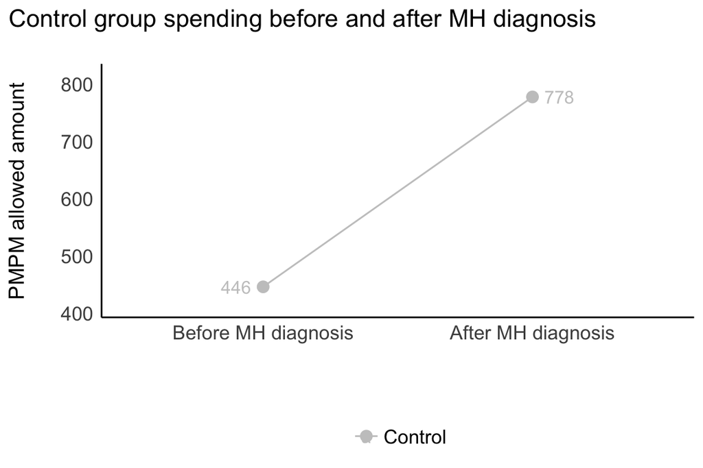

```r
df_plot <- df_matched %>%
  distinct(spring_dummy, phase) %>%
  cbind(cust_recode) %>%
  mutate(
    phase_label = case_when(
      phase == "pre_tx" ~ "Before MH diagnosis",
      phase == "post_tx" ~ "After MH diagnosis"
    )
  ) %>%
  mutate(phase_label = factor(phase_label, levels = c("Before MH diagnosis", "After MH diagnosis")))

df_plot <- predictions(m1_gross_yes_match, newdata = df_plot, re.form = ~0)

color_scheme <- c('#c7c7c7', "#37837c")

# Control only
df_plot_control <- filter(df_plot, spring_dummy == "Health Plan")
ggplot(df_plot_control, aes(x=phase_label, y=estimate, ymin=conf.low, ymax=conf.high, group = spring_dummy, color = spring_dummy)) +
  geom_point(size=3) +
  geom_line() +
  scale_color_manual(values = color_scheme, labels = c("Control", "Spring Health")) +
  geom_text_repel(aes(label=round(estimate, 0)), hjust = ifelse(df_plot_control$phase_label == "Before MH diagnosis", 1.4, -0.4)) +
  theme_modern() +
  theme(legend.position = "bottom") +
  labs(
    title = "Control group spending before and after MH diagnosis",
    x = "",
    y = "PMPM allowed amount",
    color = ""
  )
```

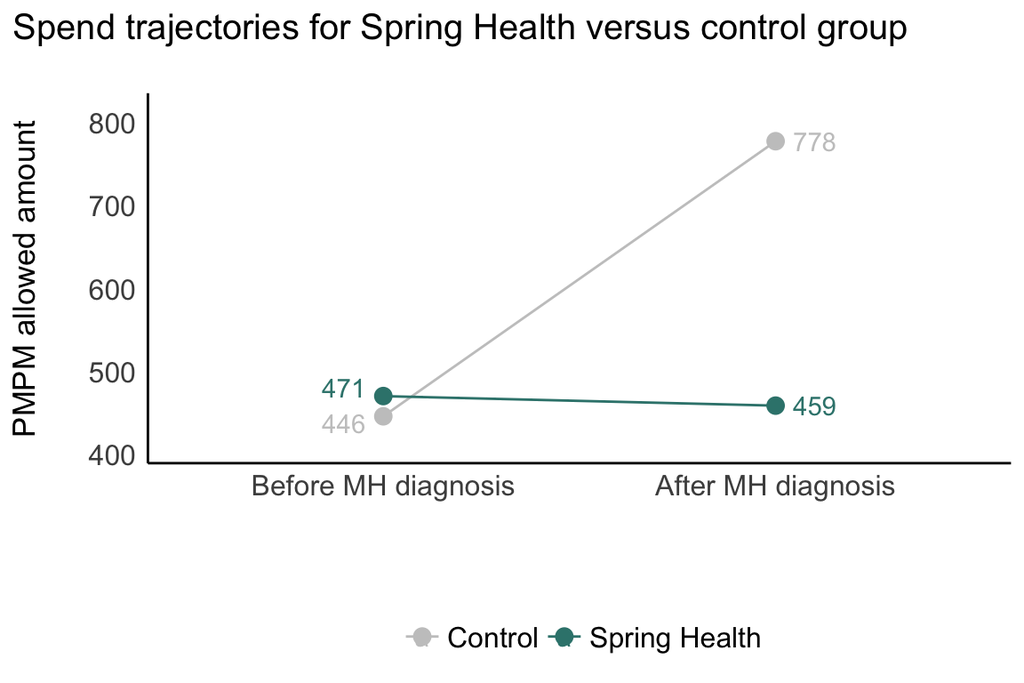

```r
# Overall, no error bars
ggplot(df_plot, aes(x=phase_label, y=estimate, ymin=conf.low, ymax=conf.high, group = spring_dummy, color = spring_dummy)) +
  geom_point(size=3) +
  geom_line() +
  scale_color_manual(values = color_scheme, labels = c("Control", "Spring Health")) +
  geom_text_repel(aes(label=round(estimate, 0)), hjust = ifelse(df_plot$phase_label == "Before MH diagnosis", 1.4, -0.4)) +
  theme_modern() +
  theme(legend.position = "bottom") +
  labs(
    title = "Spend trajectories for Spring Health versus control group",
    x = "",
    y = "PMPM allowed amount",
    color = ""
  )
```

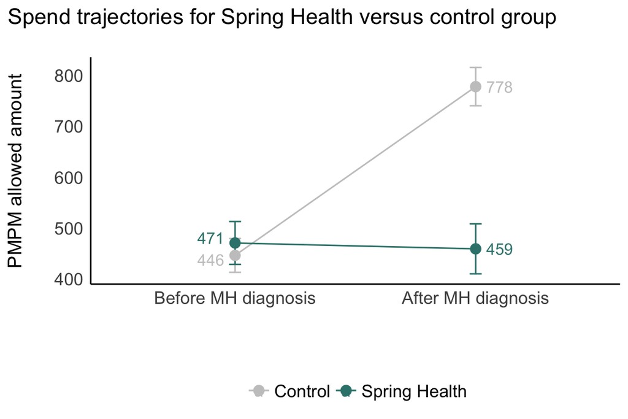

```r
# Overall with error bars
ggplot(df_plot, aes(x=phase_label, y=estimate, ymin=conf.low, ymax=conf.high, group = spring_dummy, color = spring_dummy)) +
  geom_errorbar(width = 0.05) +
  geom_point(size=3) +
  geom_line() +
  scale_color_manual(values = color_scheme, labels = c("Control", "Spring Health")) +
  geom_text_repel(aes(label=round(estimate, 0)), hjust = ifelse(df_plot$phase_label == "Before MH diagnosis", 1.4, -0.4)) +
  theme_modern() +
  theme(legend.position = "bottom") +
  labs(
    title = "Spend trajectories for Spring Health versus control group",
    x = "",
    y = "PMPM allowed amount",
    color = ""
  )
```

## 4.3 Spring impact at participant 1-year follow-up

```r
m_1yr_participant <- lmer(med_pmpm_trunc ~ 1 + spring_dummy + as.factor(months_post) +
                          spring_dummy*as.factor(months_post) +
                             (1 | carrier_member_id) +
                             (1 | subclass_nn),
                           weights = weights_nn,
                           data = df_matched)

tab_model(m_1yr_participant, show.ci=F, show.se=T)
```

|  | med pmpm trunc |  |  |
| --- | --- | --- | --- |
| Predictors | Estimates | std. Error | p |
| (Intercept) | 442.59 | 17.04 | **<0.001** |
| spring dummy [Spring] | 23.51 | 23.44 | 0.316 |
| months post1 | 939.92 | 35.56 | **<0.001** |
| months post2 | 321.38 | 35.99 | **<0.001** |
| months post3 | 318.71 | 37.69 | **<0.001** |
| months post4 | 220.08 | 39.59 | **<0.001** |
| months post5 | 149.97 | 42.19 | **<0.001** |
| months post6 | 129.08 | 45.90 | **0.005** |
| months post7 | 161.11 | 49.77 | **0.001** |
| months post8 | 233.90 | 55.17 | **<0.001** |
| months post9 | 164.61 | 60.76 | **0.007** |
| months post10 | 146.66 | 67.00 | **0.029** |
| months post11 | 131.59 | 77.24 | 0.088 |
| months post12 | 75.25 | 93.11 | 0.419 |
| spring dummy [Spring] × months post1 | -890.57 | 60.87 | **<0.001** |
| spring dummy [Spring] × months post2 | -366.16 | 61.70 | **<0.001** |
| spring dummy [Spring] × months post3 | -266.11 | 64.76 | **<0.001** |
| spring dummy [Spring] × months post4 | -189.21 | 67.95 | **0.005** |
| spring dummy [Spring] × months post5 | -237.03 | 72.84 | **0.001** |
| spring dummy [Spring] × months post6 | -187.67 | 79.62 | **0.018** |
| spring dummy [Spring] × months post7 | -207.57 | 86.98 | **0.017** |
| spring dummy [Spring] × months post8 | -316.36 | 97.62 | **0.001** |
| spring dummy [Spring] × months post9 | -178.27 | 107.92 | 0.099 |
| spring dummy [Spring] × months post10 | -218.26 | 118.94 | 0.066 |
| spring dummy [Spring] × months post11 | -169.15 | 136.85 | 0.216 |
| spring dummy [Spring] × months post12 | 30.53 | 166.95 | 0.855 |
| Random Effects |  |  |  |
| σ<sup>2</sup> | 8230140.24 |  |  |
| τ<sub>00</sub> <sub>carrier_member_id</sub> | 596487.20 |  |  |
| τ<sub>00</sub> <sub>subclass_nn</sub> | 377077.55 |  |  |
| ICC | 0.11 |  |  |
| N <sub>carrier_member_id</sub> | 10716 |  |  |
| N <sub>subclass_nn</sub> | 3643 |  |  |
| Observations | 195540 |  |  |
| Marginal R<sup>2</sup> / Conditional R<sup>2</sup> | 0.004 / 0.109 |  |  |

```r
# Get PPPY in dollars
hypotheses(m_1yr_participant, hypothesis = "b15 + b16 + b17 + b18 + b19 + b20 + b21 + b22 + b23 + b24 + b25 + b26 = 0")
```

```
##
##                                                                       Term
##  b15 + b16 + b17 + b18 + b19 + b20 + b21 + b22 + b23 + b24 + b25 + b26 = 0
##  Estimate Std. Error     z Pr(>|z|) 2.5 % 97.5 %
##     -3196        408 -7.84   <0.001 -3995  -2397
##
## Columns: term, estimate, std.error, statistic, p.value, conf.low, conf.high
```

```r
# Get PPPY in pct
hypotheses(m_1yr_participant, hypothesis = "(b15 + b16 + b17 + b18 + b19 + b20 + b21 + b22 + b23 + b24 + b25 + b26) /
          (b1*12 + b3 + b4 + b5 + b6 + b7 + b8 + b9 + b10 + b11 + b12 + b13 + b14)  = 0")
```

```
##
##                                                                                                                                                                Term
##  (b15 + b16 + b17 + b18 + b19 + b20 + b21 + b22 + b23 + b24 + b25 + b26) /\n          (b1*12 + b3 + b4 + b5 + b6 + b7 + b8 + b9 + b10 + b11 + b12 + b13 + b14)  = 0
##  Estimate Std. Error     z Pr(>|z|)  2.5 % 97.5 %
##    -0.385      0.046 -8.37   <0.001 -0.475 -0.295
##
## Columns: term, estimate, std.error, statistic, p.value, conf.low, conf.high
```

## 4.4 Spring effect on Rx

```r
# Only run rx models if client has rx data
## No matching
m1_rx_no_match <- lmer(rx_pmpm_trunc ~ 1 + spring_dummy + spring_dummy*phase + customer_name +
             (1 | carrier_member_id),
           data = filter(df_analyze_all, index_date >= spring_start_date))

## Matching
m1_rx_yes_match <- lmer(rx_pmpm_trunc ~ 1 + spring_dummy + spring_dummy*phase + customer_name +
             (1 | carrier_member_id) +
             (1 | subclass_nn),
           weights = weights_nn,
           data = df_matched)

tab_model(m1_rx_no_match, m1_rx_yes_match, show.ci=F, show.se=T,
          pred.labels = c("Baseline PMPM", "Baseline difference (Spring - Control)", "Control pre-post change", "Diff-in-diff (Spring change - Control change)"),
          dv.labels = c("Umatched", "Matched", "Exclude pregnancy"),
          title = "Spring effect on gross pharmacy spending")
```

Spring effect on gross pharmacy spending

|  | Umatched |  |  | Matched |  |  | Exclude pregnancy |
| --- | --- | --- | --- | --- | --- | --- | --- |
| Predictors | Estimates | std. Error | p | Estimates | std. Error | p |  |
| (Intercept) | 189.18 | 30.02 | **<0.001** | 86.66 | 33.30 | **0.009** |  |
| spring_dummySpring | -16.10 | 17.41 | 0.355 | 19.04 | 14.98 | 0.204 |  |
| phasepost_tx | 41.39 | 2.62 | **<0.001** | 43.22 | 4.76 | **<0.001** |  |
| customer_nameHearst | -200.40 | 35.74 | **<0.001** | -108.38 | 41.40 | **0.009** |  |
| customer_namePepsi | -25.43 | 30.45 | 0.404 | 48.64 | 35.21 | 0.167 |  |
| customer_nameTegna | -199.11 | 38.00 | **<0.001** | -107.57 | 42.39 | **0.011** |  |
| customer_nameWellstar | 58.10 | 32.76 | 0.076 | 108.72 | 37.50 | **0.004** |  |
| spring_dummySpring:phasepost_tx | -1.30 | 8.54 | 0.879 | -3.24 | 8.23 | 0.694 |  |
| Random Effects |  |  |  |  |  |  |  |
| σ<sup>2</sup> | 948899.50 |  |  | 648118.31 |  |  |  |
| τ<sub>00</sub> | 870610.21 <sub>carrier_member_id</sub> |  |  | 481074.77 <sub>carrier_member_id</sub> |  |  |  |
|  |  |  |  | 103239.98 <sub>subclass_nn</sub> |  |  |  |
| ICC | 0.48 |  |  | 0.47 |  |  |  |
| N | 35417 <sub>carrier_member_id</sub> |  |  | 10716 <sub>carrier_member_id</sub> |  |  |  |
|  |  |  |  | 3643 <sub>subclass_nn</sub> |  |  |  |
| Observations | 676348 |  |  | 195551 |  |  |  |
| Marginal R<sup>2</sup> / Conditional R<sup>2</sup> | 0.003 / 0.480 |  |  | 0.005 / 0.477 |  |  |  |

## 4.5 Chronic conditions

```r
# Aggregate by mental health spend
df_matched <- df_matched %>%
  mutate(
    med_pmpm_trunc_mh =
      med_pmpm_trunc_therapy_mh +
      med_pmpm_trunc_ov_mh +
      med_pmpm_trunc_er_mh +
      med_pmpm_trunc_ip_mh +
      med_pmpm_trunc_hosp_op_mh +
      med_pmpm_trunc_other_mh,
    med_pmpm_trunc_nonmh =
      med_pmpm_trunc_therapy_nonmh +
      med_pmpm_trunc_ov_nonmh +
      med_pmpm_trunc_er_nonmh +
      med_pmpm_trunc_ip_nonmh +
      med_pmpm_trunc_hosp_op_nonmh +
      med_pmpm_trunc_other_nonmh
  )

# Model
m1 <- lmer(med_pmpm_trunc_mh ~ 1 + spring_dummy + spring_dummy*phase +
             cc_diabetes + cc_diabetes*(spring_dummy + spring_dummy*phase) +
             customer_name +
             (1 | carrier_member_id) +
             (1 | subclass_nn),
           weights = weights_nn,
           data = df_matched)

m2 <- lmer(med_pmpm_trunc_mh ~ 1 + spring_dummy + spring_dummy*phase +
             cc_hypertension + cc_hypertension*(spring_dummy + spring_dummy*phase) +
             customer_name +
             (1 | carrier_member_id) +
             (1 | subclass_nn),
           weights = weights_nn,
           data = df_matched)

m3 <- lmer(med_pmpm_trunc_mh ~ 1 + spring_dummy + spring_dummy*phase +
             cc_asthma_copd + cc_asthma_copd*(spring_dummy + spring_dummy*phase) +
             customer_name +
             (1 | carrier_member_id) +
             (1 | subclass_nn),
           weights = weights_nn,
           data = df_matched)

m4 <- lmer(med_pmpm_trunc_mh ~ 1 + spring_dummy + spring_dummy*phase +
             excl_pregnancy + excl_pregnancy*(spring_dummy + spring_dummy*phase) +
             customer_name +
             (1 | carrier_member_id) +
             (1 | subclass_nn),
           weights = weights_nn,
           data = df_matched)

m5 <- lmer(med_pmpm_trunc_mh ~ 1 + spring_dummy + spring_dummy*phase +
             cc_cancer + cc_cancer*(spring_dummy + spring_dummy*phase) +
             customer_name +
             (1 | carrier_member_id) +
             (1 | subclass_nn),
           weights = weights_nn,
           data = df_matched)

m6 <- lmer(med_pmpm_trunc_nonmh ~ 1 + spring_dummy + spring_dummy*phase +
             cc_diabetes + cc_diabetes*(spring_dummy + spring_dummy*phase) +
             customer_name +
             (1 | carrier_member_id) +
             (1 | subclass_nn),
           weights = weights_nn,
           data = df_matched)

m7 <- lmer(med_pmpm_trunc_nonmh ~ 1 + spring_dummy + spring_dummy*phase +
             cc_hypertension + cc_hypertension*(spring_dummy + spring_dummy*phase) +
             customer_name +
             (1 | carrier_member_id) +
             (1 | subclass_nn),
           weights = weights_nn,
           data = df_matched)

m8 <- lmer(med_pmpm_trunc_nonmh ~ 1 + spring_dummy + spring_dummy*phase +
             cc_asthma_copd + cc_asthma_copd*(spring_dummy + spring_dummy*phase) +
             customer_name +
             (1 | carrier_member_id) +
             (1 | subclass_nn),
           weights = weights_nn,
           data = df_matched)

m9 <- lmer(med_pmpm_trunc_nonmh ~ 1 + spring_dummy + spring_dummy*phase +
             excl_pregnancy + excl_pregnancy*(spring_dummy + spring_dummy*phase) +
             customer_name +
             (1 | carrier_member_id) +
             (1 | subclass_nn),
           weights = weights_nn,
           data = df_matched)

m10 <- lmer(med_pmpm_trunc_nonmh ~ 1 + spring_dummy + spring_dummy*phase +
             cc_cancer + cc_cancer*(spring_dummy + spring_dummy*phase) +
             customer_name +
             (1 | carrier_member_id) +
             (1 | subclass_nn),
           weights = weights_nn,
           data = df_matched)

m_all_mh <- lmer(med_pmpm_trunc_mh ~ 1 + spring_dummy + spring_dummy*phase +
                   customer_name +
             (1 | carrier_member_id) +
             (1 | subclass_nn),
           weights = weights_nn,
           data = df_matched)

m_all_nonmh <- lmer(med_pmpm_trunc_nonmh ~ 1 + spring_dummy + spring_dummy*phase +
                      customer_name +
             (1 | carrier_member_id) +
             (1 | subclass_nn),
           weights = weights_nn,
           data = df_matched)


m_list <- list(m1, m2, m3, m4, m5, m6, m7, m8, m9, m10)
df_cc_results <- data.frame(
  Term = NA,
  Estimate = NA,
  se = NA,
  z = NA,
  p = NA,
  lb = NA,
  ub = NA)

for (i in 1:length(m_list)) {
  df_cc_results[i,] <- hypotheses(m_list[[i]], hypothesis = "b9 + b12 = 0")
  df_cc_results[11,] <- hypotheses(m_all_mh, hypothesis = "b8 = 0") # add pop average MH
  df_cc_results[12,] <- hypotheses(m_all_nonmh, hypothesis = "b8 = 0") # add pop average non-MH
}

# Add cc names
df_cc_results <- df_cc_results %>%
  mutate(
    chronic_condition = c(
      rep(c("Diabetes", "Hypertension", "Asthma/COPD", "Pregnancy", "Cancer"), 2),
      rep("Population average", 2)
      ),
    var_name = c(
      rep(c("cc_diabetes", "cc_hypertension", "cc_asthma_copd", "excl_pregnancy", "cc_cancer"), 2),
      rep("Population average", 2)
    ),
    spend_type = c(rep("Mental healthcare savings", 5), rep("All other healthcare savings", 5), "Mental healthcare savings", "All other healthcare savings")
  )

# Add Ns
df_cc_results <- df_cc_results %>%
  left_join(
    df_matched %>%
      select(carrier_member_id, spring_dummy, any_of(df_cc_results$var_name)) %>%
      group_by(spring_dummy) %>%
      summarize(across(everything(), ~ n_distinct(carrier_member_id[.x == "yes"]))) %>%
      select(-carrier_member_id) %>%
      pivot_longer(-spring_dummy, names_to = "var_name", values_to = "N") %>%
      pivot_wider(id_cols = var_name, names_from = spring_dummy, values_from = N, names_prefix = "N from ")
  ) %>%
  mutate(
    "N from Health Plan" = case_when(
      chronic_condition == "Population average" ~ n_distinct(df_matched$carrier_member_id[df_matched$spring_dummy == "Health Plan"]),
      TRUE ~ `N from Health Plan`
    ),
    "N from Spring" = case_when(
      chronic_condition == "Population average" ~ n_distinct(df_matched$carrier_member_id[df_matched$spring_dummy == "Spring"]),
      TRUE ~ `N from Spring`
    )
  ) %>%
  relocate(chronic_condition, `N from Spring`, `N from Health Plan`) %>%
  select(-c(Term, var_name, z))
```

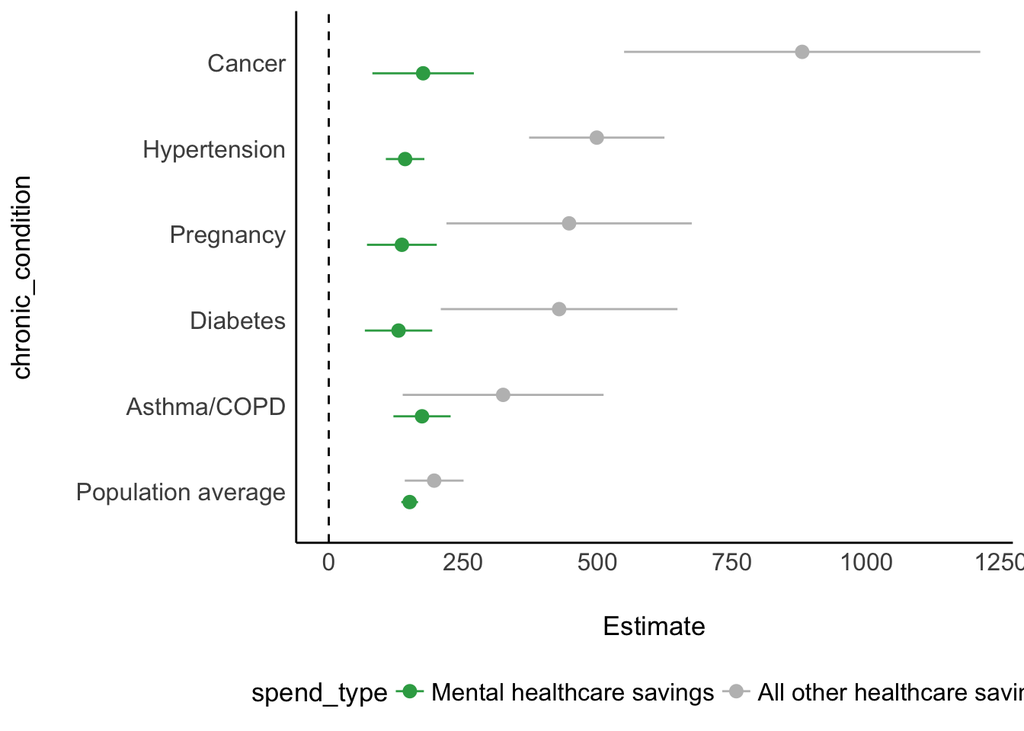

```r
## Make it nice
cc_colors <- c("#34a853", "grey")
df_plot_cc <- df_cc_results %>%
  mutate(
    Estimate = -1*Estimate,
    lb = -1*lb,
    ub = -1*ub
  ) %>%
  mutate(
    chronic_condition = fct_reorder(as.factor(chronic_condition), Estimate),
    spend_type = fct_relevel(spend_type,"Mental healthcare savings", "All other healthcare savings")
    )

## Let's plot with CIs so we can understand it
ggplot(df_plot_cc, aes(x=Estimate, xmin=lb, xmax=ub, y=chronic_condition, color = spend_type)) +
  geom_pointrange(position = position_dodge(width=0.5)) +
  scale_color_manual(values = cc_colors) +
  geom_vline(xintercept = 0, linetype = "dashed") +
  theme_modern() +
  theme(legend.position = "bottom")
```

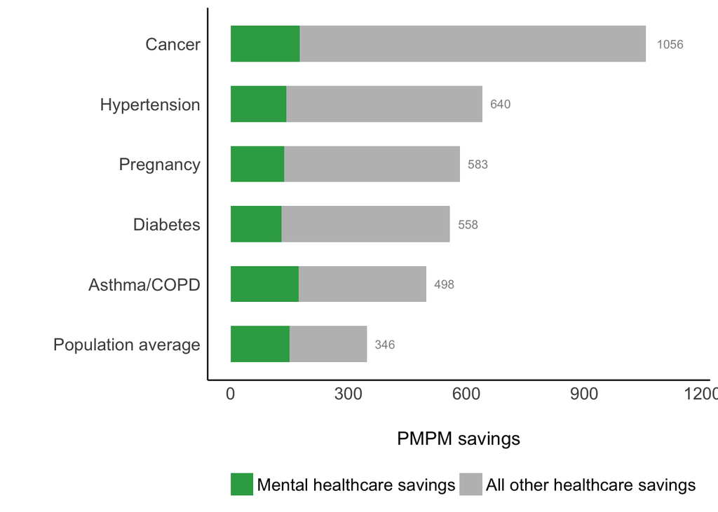

```r
## For barplot, we want overall value laels
df_labels <- df_plot_cc %>%
  group_by(chronic_condition) %>%
  summarize(total = sum(Estimate))


ggplot(df_plot_cc, aes(x=Estimate, y=chronic_condition, fill = spend_type)) +
  geom_bar(stat = "identity", width = 0.6, position=position_stack(reverse=T)) +
  scale_fill_manual(values = cc_colors) +
  geom_text(aes(x=total, y=chronic_condition, label = round(total, 0), fill = NULL, hjust = ifelse(total < 0, 1.1, -0.4)), colour = "#8e8e8e", size = 3, data = df_labels) +
  expand_limits(x=c(0, 1.1*max(df_labels$total))) +
  theme_modern() +
  theme(legend.position = "bottom") +
  labs(
    x = "PMPM savings",
    y = "",
    fill = " "
  )
```

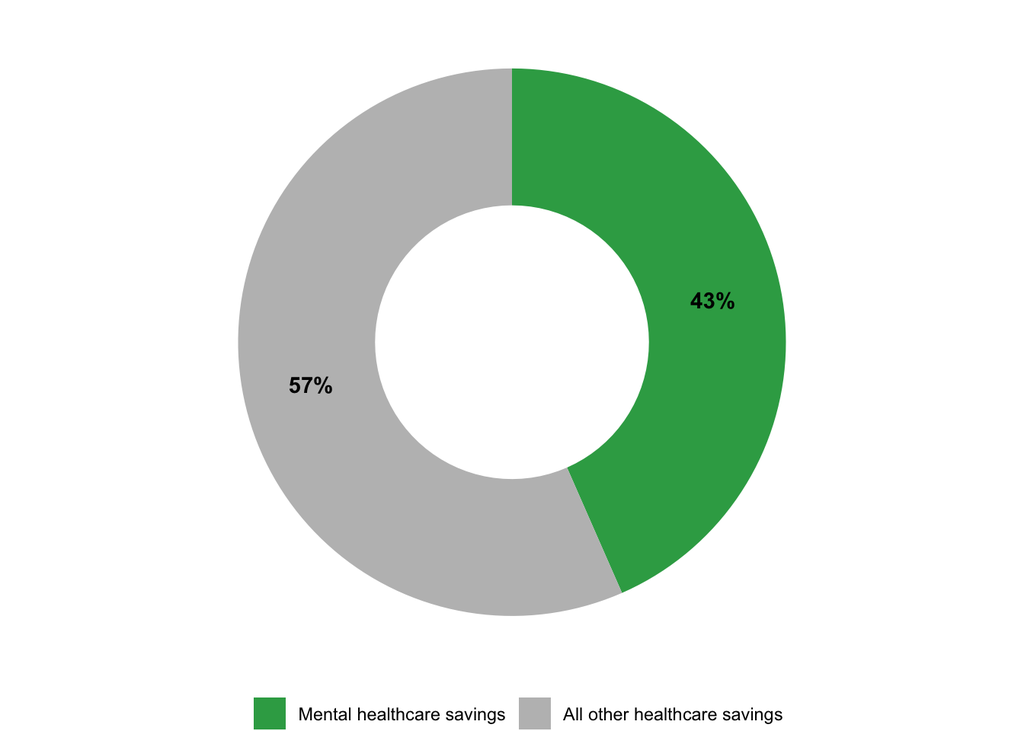

```r
## Add donut chart *gag*
# Compute percentages
df_donut <- df_plot_cc %>%
  filter(chronic_condition == "Population average") %>%
  group_by(spend_type) %>%
  summarize(total = sum(Estimate)) %>%
  ungroup() %>%
  mutate(fraction = total / sum(total)) %>%
  mutate(
    ymax = cumsum(fraction),
    ymin = c(0, head(ymax, n=-1))
    ) %>%
  mutate(labelPosition = (ymax + ymin) /2)


# Make the plot
ggplot(df_donut, aes(ymax=ymax, ymin=ymin, xmax=4, xmin=3, fill=spend_type)) +
     geom_rect() +
     coord_polar(theta="y") +
     xlim(c(2, 4)) +
  theme_modern() +
  theme_void() +
  scale_fill_manual(values = cc_colors) +
  geom_text(aes(x=3.5, y=labelPosition, label=paste0(100*round(df_donut$fraction, 2), "%")), fontface = "bold") +
  labs(fill = "") +
  theme(legend.position = "bottom")
```

## 4.6 Outcomes by MH disorder

```r
# Models
sud_overall <- lmer(med_pmpm_trunc ~ 1 + spring_dummy + spring_dummy*phase +
                             (1 | carrier_member_id) +
                             (1 | subclass_nn),
                           #weights = weights_nn,
                           data = filter(df_matched, dx_imputed == "sud"))


mh_mood <- lmer(med_pmpm_trunc_mh ~ 1 + spring_dummy + spring_dummy*phase +
                       (1 | carrier_member_id) +
                       (1 | subclass_nn),
                     weights = weights_nn,
                     data = filter(df_matched, dx_imputed == "mood"))

mh_anxiety <- lmer(med_pmpm_trunc_mh ~ 1 + spring_dummy + spring_dummy*phase +
                        (1 | carrier_member_id) +
                        (1 | subclass_nn),
                      weights = weights_nn,
                      data = filter(df_matched, dx_imputed == "anxiety"))

mh_sud <- lmer(med_pmpm_trunc_mh ~ 1 + spring_dummy + spring_dummy*phase +
                             (1 | carrier_member_id) +
                             (1 | subclass_nn),
                           #weights = weights_nn,
                           data = filter(df_matched, dx_imputed == "sud"))

nonmh_mood <- lmer(med_pmpm_trunc_nonmh ~ 1 + spring_dummy + spring_dummy*phase +
                       (1 | carrier_member_id) +
                       (1 | subclass_nn),
                     weights = weights_nn,
                     data = filter(df_matched, dx_imputed == "mood"))

nonmh_anxiety <- lmer(med_pmpm_trunc_nonmh ~ 1 + spring_dummy + spring_dummy*phase +
                        (1 | carrier_member_id) +
                        (1 | subclass_nn),
                      weights = weights_nn,
                      data = filter(df_matched, dx_imputed == "anxiety"))

nonmh_sud <- lmer(med_pmpm_trunc_nonmh ~ 1 + spring_dummy + spring_dummy*phase +
                             (1 | carrier_member_id) +
                             (1 | subclass_nn),
                           #weights = weights_nn,
                           data = filter(df_matched, dx_imputed == "sud"))

dx_list <- list(mh_mood, mh_anxiety, mh_sud, nonmh_mood, nonmh_anxiety, nonmh_sud)

df_dx_results <- data.frame(
  Term = NA,
  Estimate = NA,
  se = NA,
  z = NA,
  p = NA,
  lb = NA,
  ub = NA)

for (i in 1:length(dx_list)) {
  df_dx_results[i,] <- hypotheses(dx_list[[i]], hypothesis = "b4 = 0")
  df_dx_results[7,] <- hypotheses(m_all_mh, hypothesis = "b8 = 0") # add pop average MH
  df_dx_results[8,] <- hypotheses(m_all_nonmh, hypothesis = "b8 = 0") # add pop average non-MH
}

# Add cc names
df_dx_results <- df_dx_results %>%
  mutate(
    mh_diagnosis = c(
      rep(c("Mood", "Anxiety", "SUD"), 2),
      rep("Population average", 2)
      ),
    var_name = c(
      rep(c("mood", "anxiety", "sud"), 2),
      rep("Population average", 2)
    ),
    spend_type = c(rep("Mental healthcare savings", 3), rep("All other healthcare savings", 3), "Mental healthcare savings", "All other healthcare savings")
  )
```

## 4.7 Plot MH disorders

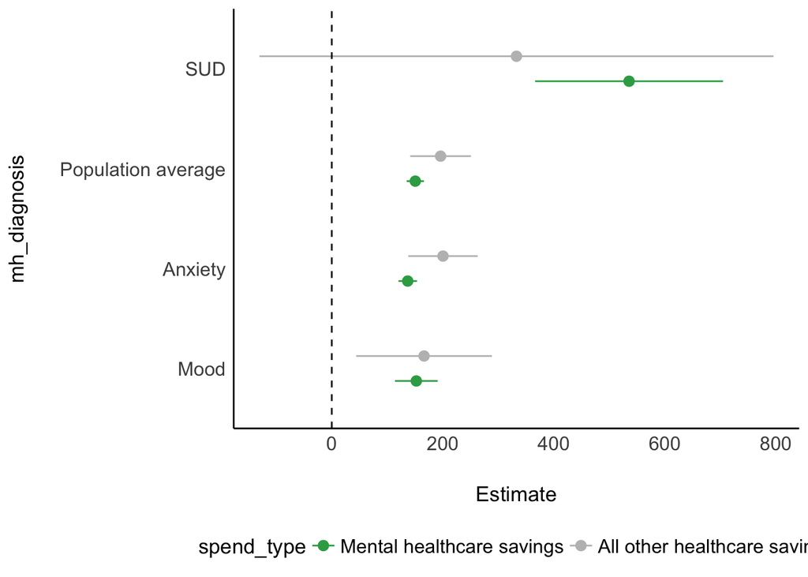

```r
## Make it nice
cc_colors <- c("#34a853", "grey")
df_plot_dx <- df_dx_results %>%
  mutate(
    Estimate = -1*Estimate,
    lb = -1*lb,
    ub = -1*ub
  ) %>%
  mutate(
    mh_diagnosis = fct_reorder(as.factor(mh_diagnosis), Estimate),
    spend_type = fct_relevel(spend_type,"Mental healthcare savings", "All other healthcare savings")
    )

## Let's plot with CIs so we can understand it
ggplot(df_plot_dx, aes(x=Estimate, xmin=lb, xmax=ub, y=mh_diagnosis, color = spend_type)) +
  geom_pointrange(position = position_dodge(width=0.5)) +
  scale_color_manual(values = cc_colors) +
  geom_vline(xintercept = 0, linetype = "dashed") +
  theme_modern() +
  theme(legend.position = "bottom")
```

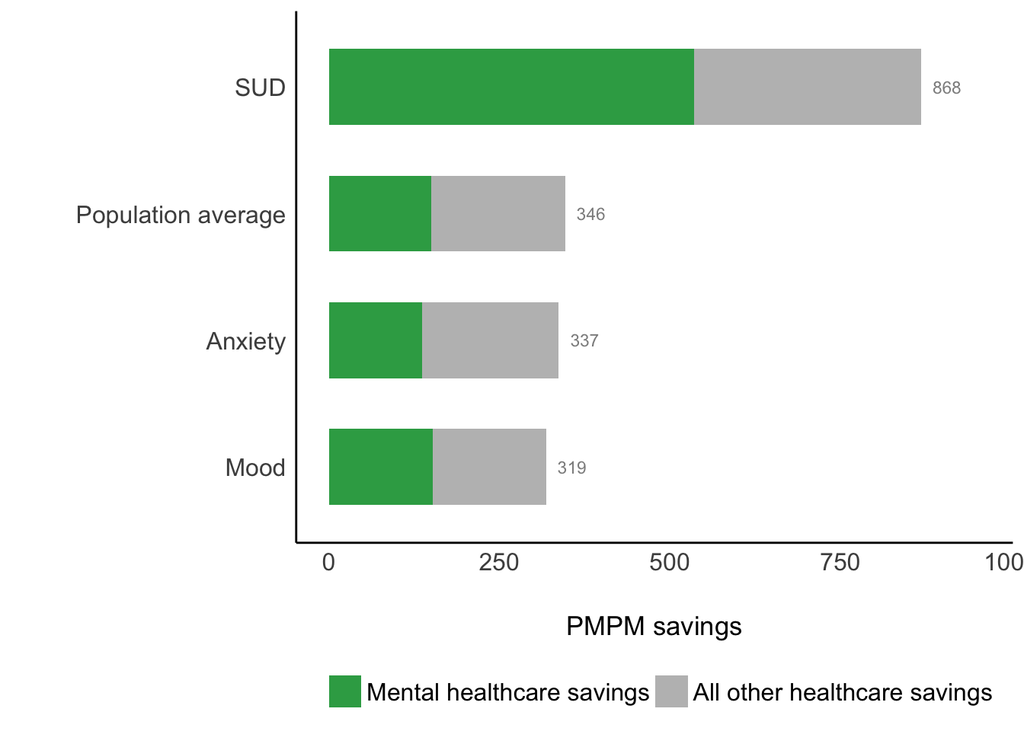

```r
## For barplot, we want overall value laels
df_labels <- df_plot_dx %>%
  group_by(mh_diagnosis) %>%
  summarize(total = sum(Estimate))


# Bar plot
ggplot(df_plot_dx, aes(x=Estimate, y=mh_diagnosis, fill = spend_type)) +
  geom_bar(stat = "identity", width = 0.6, position=position_stack(reverse=T)) +
  scale_fill_manual(values = cc_colors) +
  geom_text(aes(x=total, y=mh_diagnosis, label = round(total, 0), fill = NULL, hjust = ifelse(total < 0, 1.1, -0.4)), colour = "#8e8e8e", size = 3, data = df_labels) +
  expand_limits(x=c(0, 1.1*max(df_labels$total))) +
  theme_modern() +
  theme(legend.position = "bottom") +
  labs(
    x = "PMPM savings",
    y = "",
    fill = " "
  )
```

```r
# Line plot
#df_plot_sud <- df_matched %>%
#  distinct(spring_dummy, phase) %>%
#  mutate(
#    phase_label = case_when(
#      phase == "pre_tx" ~ "Before MH diagnosis",
#      phase == "post_tx" ~ "After MH diagnosis"
#    )
#  ) %>%
#  mutate(phase_label = factor(phase_label, levels = c("Before MH diagnosis", "After MH diagnosis")))
#
#df_plot_sud <- predictions(m1_gross_yes_match, newdata = df_plot, re.form = ~0)
#
#color_scheme <- c('#c7c7c7', "#37837c")
#
#
## Overall with error bars
#ggplot(df_plot, aes(x=phase_label, y=estimate, ymin=conf.low, ymax=conf.high, group = spring_dummy, color = spring_dummy)) +
#  geom_errorbar(width = 0.05) +
#  geom_point(size=3) +
#  geom_line() +
#  scale_color_manual(values = color_scheme, labels = c("Control", "Spring Health")) +
#  geom_text_repel(aes(label=round(estimate, 0)), hjust = ifelse(df_plot$phase_label == "Before MH diagnosis", 1.4, -0.4)) +
#  theme_modern() +
#  theme(legend.position = "bottom") +
#  labs(
#    title = "Spend trajectories for Spring Health versus control group",
#    x = "",
#    y = "PMPM allowed amount",
#    color = ""
#  )
```

## 4.8 Cost categories

```r
cc1 <- lmer(med_pmpm_trunc_ov_mh ~ 1 + spring_dummy + spring_dummy*phase +
              customer_name +
              (1 | carrier_member_id) +
              (1 | subclass_nn),
            weights = weights_nn,
            data = df_matched)

cc2 <- lmer(med_pmpm_trunc_er_mh ~ 1 + spring_dummy + spring_dummy*phase +
              customer_name +
              (1 | carrier_member_id) +
              (1 | subclass_nn),
            weights = weights_nn,
            data = df_matched)

cc3 <- lmer(med_pmpm_trunc_hosp_op_mh ~ 1 + spring_dummy + spring_dummy*phase +
              customer_name +
              (1 | carrier_member_id) +
              (1 | subclass_nn),
            weights = weights_nn,
            data = df_matched)

cc4 <- lmer(med_pmpm_trunc_ip_mh ~ 1 + spring_dummy + spring_dummy*phase +
              customer_name +
              (1 | carrier_member_id) +
              (1 | subclass_nn),
            weights = weights_nn,
            data = df_matched)

## Non-MH
cc5 <- lmer(med_pmpm_trunc_ov_nonmh ~ 1 + spring_dummy + spring_dummy*phase +
              customer_name +
              (1 | carrier_member_id) +
              (1 | subclass_nn),
            weights = weights_nn,
            data = df_matched)

cc6 <- lmer(med_pmpm_trunc_er_nonmh ~ 1 + spring_dummy + spring_dummy*phase +
              customer_name +
              (1 | carrier_member_id) +
              (1 | subclass_nn),
            weights = weights_nn,
            data = df_matched)

cc7 <- lmer(med_pmpm_trunc_hosp_op_nonmh ~ 1 + spring_dummy + spring_dummy*phase +
              customer_name +
              (1 | carrier_member_id) +
              (1 | subclass_nn),
            weights = weights_nn,
            data = df_matched)

cc8 <- lmer(med_pmpm_trunc_ip_nonmh ~ 1 + spring_dummy + spring_dummy*phase +
              customer_name +
              (1 | carrier_member_id) +
              (1 | subclass_nn),
            weights = weights_nn,
            data = df_matched)


# Make in table
df_cost_results <- data.frame(
  outcome = rep(c("Office visits", "Emergency room", "Hospital outpatient", "Hospital inpatient"), 2),
  spend_type = c(rep("Mental healthcare savings", 4), rep("All other healthcare savings", 4)),
  estimate = NA,
  se = NA
) %>%
  mutate(outcome = fct_relevel(as.factor(outcome), "Office visits", "Emergency room", "Hospital outpatient", "Hospital inpatient"))

for (i in 1:8) {
  df_cost_results$estimate[i] = summary(get(paste0("cc", i)))$coefficients["spring_dummySpring:phasepost_tx", "Estimate"]
  df_cost_results$se[i] = summary(get(paste0("cc", i)))$coefficients["spring_dummySpring:phasepost_tx", "Std. Error"]
}

df_cost_results %>%
  group_by(outcome) %>%
  summarize(total = sum(estimate)) %>%
  mutate(total = round(total, 0))
```

```
## # A tibble: 4 × 2
##   outcome             total
##   <fct>               <dbl>
## 1 Office visits         -29
## 2 Emergency room        -22
## 3 Hospital outpatient  -113
## 4 Hospital inpatient   -127
```

```r
df_donut_cc <- df_cost_results %>%
  group_by(outcome) %>%
  mutate(fraction = estimate/sum(estimate)) %>%
  mutate(
    ymax = cumsum(fraction),
    ymin = c(0, head(ymax, n=-1))
    ) %>%
  ungroup() %>%
  mutate(labelPosition = (ymax + ymin) /2) %>%
  mutate(spend_type = fct_relevel(spend_type,"Mental healthcare savings", "All other healthcare savings"))


# Make the plots
donut_list <- list()
outcome_list <- unique(df_donut_cc$outcome)

for (i in 1:length(outcome_list)) {
donut_list[[i]] <- ggplot(filter(df_donut_cc, outcome == outcome_list[[i]]), aes(ymax=ymax, ymin=ymin, xmax=4, xmin=3, fill=spend_type)) +
     geom_rect() +
     coord_polar(theta="y") +
     xlim(c(2, 4)) +
  scale_fill_manual(values = cc_colors) +
  theme_modern() +
  theme_void() +
  theme(legend.position = "none") +
  labs(fill = "")
}


# Make the table
df_donut_cc %>%
  group_by(outcome) %>%
  summarize(total = -1*sum(estimate)) %>%
  mutate(Description = c(
    "Less mental health care delivered in an inappropriate setting by primary care providers",
    "Lower utilization of high-cost emerency room services",
    "Getting patients the mental health care they need decreases excess outpatient medical spending",
    "Greater adherence to care plans keeps Spring patients out of the hospital setting, where diagnostic tests and high-cost procedures can drive unnecessary spend"
  )) %>%
  mutate(total = scales::dollar_format()(round(total, 0))) %>%
  mutate("% Savings from mental health" = NA) %>% # Make placeholder for plot
  rename(
    "Service category" = outcome,
    "PMPM savings" = total
  ) %>%
  relocate(Description, .after = "Service category") %>%
  tibble() %>%
  gt() %>%
   text_transform(
    locations = cells_body(columns = `% Savings from mental health`),
    fn = function(x) {
      donut_list %>%
        ggplot_image(height = px(80))
    }
  ) %>%
  tab_options(column_labels.font.weight = "bold") %>%
  tab_style(
    style = cell_text(align = "center"),
    locations = cells_column_labels()
    ) %>%
  tab_style(
    style = cell_text(weight = "bold"),
    locations = cells_body(columns = c("Service category", "PMPM savings"))
)
```

Service category

Description

PMPM savings

% Savings from mental health

Office visits

Less mental health care delivered in an inappropriate setting by primary care providers

$29

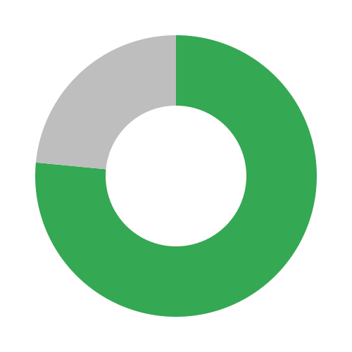

Emergency room

Lower utilization of high-cost emerency room services

$22

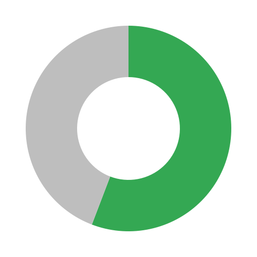

Hospital outpatient

Getting patients the mental health care they need decreases excess outpatient medical spending

$113

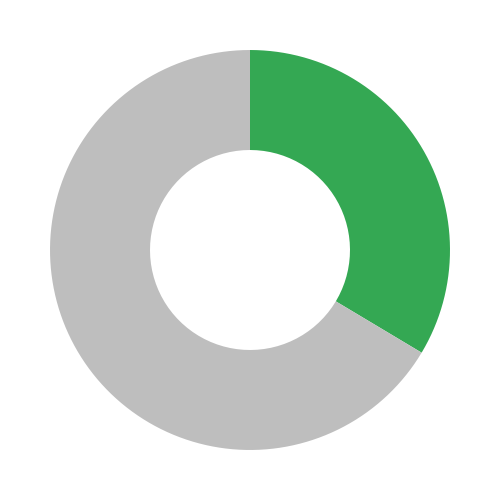

Hospital inpatient

Greater adherence to care plans keeps Spring patients out of the hospital setting, where diagnostic tests and high-cost procedures can drive unnecessary spend

$127

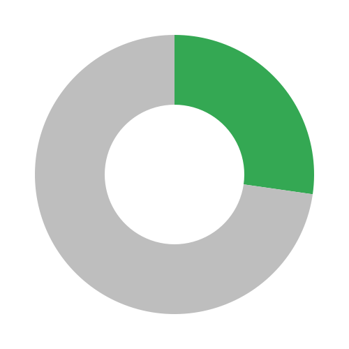

## 4.9 Therapy moderators

```r
# Calculate cumulative sessions
df_matched <- df_matched %>%
  group_by(carrier_member_id) %>%
  arrange(months) %>%
  mutate(
    therapy_sessions = case_when(
      spring_dummy == "Spring" ~ cumsum(spring_therapist_count_month),
      spring_dummy == "Health Plan" ~ cumsum(carrier_therapist_count_month)
    )
  ) %>%
  mutate(therapy_sessions_total = max(therapy_sessions, na.rm=T))

m_sessions1 <- lmer(med_pmpm_trunc ~ 1 + spring_dummy + spring_dummy*phase + Hearst + Pepsi + Tegna + Wellstar +
                     therapy_sessions +
             (1 | carrier_member_id) +
             (1 | subclass_nn),
           weights = weights_nn,
           data = df_matched)

## Should be different for Spring because spring sessions are not included in med spending costs
m_sessions2 <- lmer(med_pmpm_trunc ~ 1 + spring_dummy + spring_dummy*phase + Hearst + Pepsi + Tegna + Wellstar +
                     therapy_sessions*spring_dummy +
             (1 | carrier_member_id) +
             (1 | subclass_nn),
           weights = weights_nn,
           data = df_matched)

## Should be different for Spring because spring sessions are not included in med spending costs
m_sessions3 <- lmer(med_pmpm_trunc ~ 1 + spring_dummy + spring_dummy*phase + Hearst + Pepsi + Tegna + Wellstar +
                     therapy_sessions_total*phase*spring_dummy +
             (1 | carrier_member_id) +
             (1 | subclass_nn),
           weights = weights_nn,
           data = df_matched)

tab_model(m_sessions1, m_sessions2, show.ci=F, show.se=T)
```

|  | med pmpm trunc |  |  | med pmpm trunc |  |  |
| --- | --- | --- | --- | --- | --- | --- |
| Predictors | Estimates | std. Error | p | Estimates | std. Error | p |
| (Intercept) | 354.50 | 53.28 | **<0.001** | 355.40 | 53.30 | **<0.001** |
| spring dummy [Spring] | 24.24 | 23.45 | 0.301 | 24.17 | 23.45 | 0.303 |
| phase [post_tx] | 333.15 | 17.19 | **<0.001** | 335.65 | 17.55 | **<0.001** |
| Hearst | -23.39 | 66.26 | 0.724 | -23.88 | 66.26 | 0.719 |
| Pepsi | 107.32 | 56.36 | 0.057 | 106.56 | 56.37 | 0.059 |
| Tegna | -99.48 | 67.79 | 0.142 | -99.88 | 67.80 | 0.141 |
| Wellstar | 223.88 | 59.97 | **<0.001** | 223.08 | 59.98 | **<0.001** |
| therapy sessions | -0.82 | 2.46 | 0.740 | -2.62 | 3.53 | 0.458 |
| spring dummy [Spring] × phase [post_tx] | -341.64 | 29.62 | **<0.001** | -350.61 | 32.18 | **<0.001** |
| spring dummy [Spring] × therapy sessions |  |  |  | 3.51 | 4.92 | 0.476 |
| Random Effects |  |  |  |  |  |  |
| σ<sup>2</sup> | 8247819.36 |  |  | 8247812.94 |  |  |
| τ<sub>00</sub> | 595609.44 <sub>carrier_member_id</sub> |  |  | 595668.80 <sub>carrier_member_id</sub> |  |  |
|  | 366316.54 <sub>subclass_nn</sub> |  |  | 366345.17 <sub>subclass_nn</sub> |  |  |
| ICC | 0.10 |  |  | 0.10 |  |  |
| N | 10716 <sub>carrier_member_id</sub> |  |  | 10716 <sub>carrier_member_id</sub> |  |  |
|  | 3643 <sub>subclass_nn</sub> |  |  | 3643 <sub>subclass_nn</sub> |  |  |
| Observations | 195540 |  |  | 195540 |  |  |
| Marginal R<sup>2</sup> / Conditional R<sup>2</sup> | 0.003 / 0.107 |  |  | 0.003 / 0.107 |  |  |

## 4.10 Trajectories

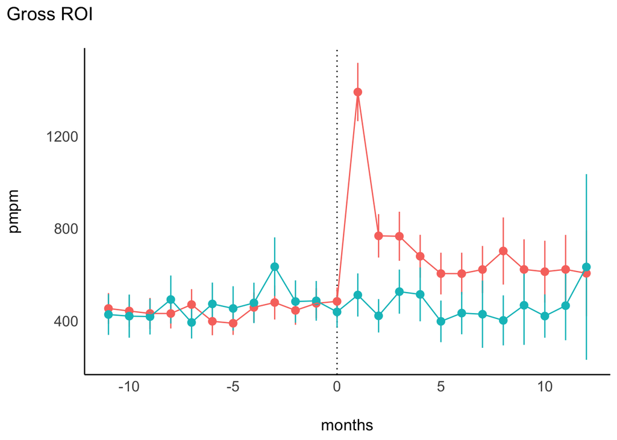

```r
library(splines)

# Fit models
m1_spline <- lmer(med_pmpm_trunc ~ 1 + spring_dummy + spring_dummy*phase +
                    spring_dummy*(ns(months_post, df = 4)) +
                    (1 | carrier_member_id) +
                    (1 | subclass_nn),
                  weights = weights_nn,
                  data = df_matched)

df_pred <- df_matched %>%
  distinct(spring_dummy, phase, months, months_post)

  df_plot_splines <- predictions(
    m1_spline,
    newdata = df_pred,
    re.form = ~0)


# Plot raw
df_matched %>%
  group_by(spring_dummy, months) %>%
  summarize(
    pmpm = mean(med_pmpm_trunc, na.rm=T),
    sd = sd(med_pmpm_trunc, na.rm=T),
    n = n_distinct(carrier_member_id),
    se = sd/sqrt(n)
    ) %>%
  filter(months <= 12) %>%
  ggplot(., aes(x=months, y=pmpm, ymin = pmpm - 1.96*se, ymax = pmpm + 1.96*se, group = spring_dummy, color=spring_dummy)) +
  geom_vline(xintercept = 0, linetype = "dotted") +
  geom_pointrange() +
  geom_line() +
  theme_modern() +
  theme(
    legend.position = "none",
    strip.text.x = element_blank()
    ) +
  labs(title = "Gross ROI")
```

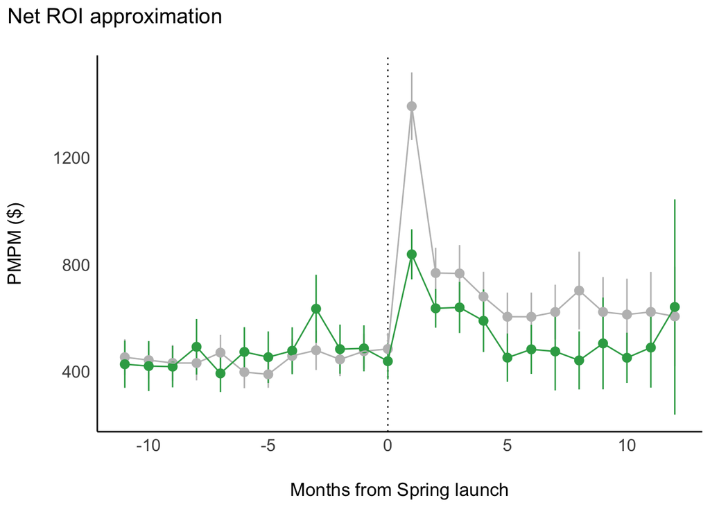

```r
## Approximate net ROI
df_matched %>%
  group_by(spring_dummy, months) %>%
  summarize(
    pmpm = mean(med_pmpm_trunc_net, na.rm=T),
    sd = sd(med_pmpm_trunc, na.rm=T),
    n = n_distinct(carrier_member_id),
    se = sd/sqrt(n)
    ) %>%
  filter(months <= 12) %>%
  ggplot(., aes(x=months, y=pmpm, ymin = pmpm - 1.96*se, ymax = pmpm + 1.96*se, group = spring_dummy, color=spring_dummy)) +
  geom_vline(xintercept = 0, linetype = "dotted") +
  geom_pointrange() +
  geom_line() +
  scale_color_manual(values = rev(cc_colors), labels = c("Control", "Spring Health")) +
  theme_modern() +
  theme(
    legend.position = "none",
    strip.text.x = element_blank()
    ) +
  labs(
    x = "Months from Spring launch",
    y = "PMPM ($)",
    title = "Net ROI approximation")
```

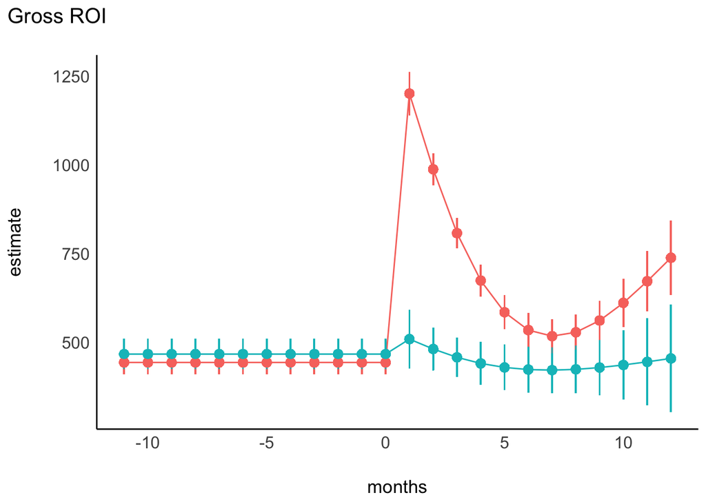

```r
# Plot splines
ggplot(df_plot_splines, aes(x=months, y=estimate, ymin = conf.low, ymax=conf.high, group = spring_dummy, color=spring_dummy)) +
  geom_line() +
  geom_pointrange() +
  theme_modern() +
  theme(
    legend.position = "none",
    strip.text.x = element_blank()
  ) +
    labs(title = "Gross ROI")
```

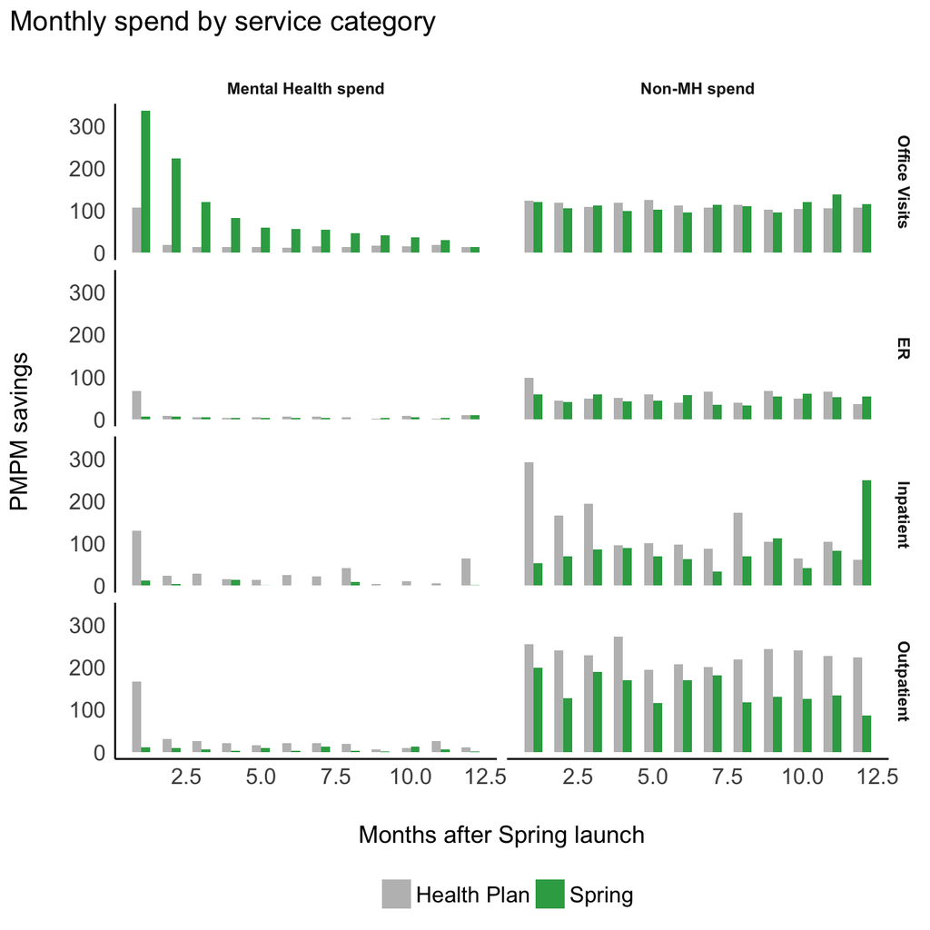

```r
df_monthly_spend <- df_matched %>%
  mutate(med_pmpm_trunc_ov_mh = med_pmpm_trunc_ov_mh + 195*spring_tx_count_month) %>% # spring spending not yet included here
  group_by(spring_dummy, months) %>%
  summarize(
    pmpm_mh_ov = mean(med_pmpm_trunc_ov_mh, na.rm=T),
    pmpm_mh_er = mean(med_pmpm_trunc_er_mh, na.rm=T),
    pmpm_mh_op = mean(med_pmpm_trunc_hosp_op_mh, na.rm=T),
    pmpm_mh_ip = mean(med_pmpm_trunc_ip_mh, na.rm=T),

    pmpm_nonmh_ov = mean(med_pmpm_trunc_ov_nonmh, na.rm=T),
    pmpm_nonmh_er = mean(med_pmpm_trunc_er_nonmh, na.rm=T),
    pmpm_nonmh_op = mean(med_pmpm_trunc_hosp_op_nonmh, na.rm=T),
    pmpm_nonmh_ip = mean(med_pmpm_trunc_ip_nonmh, na.rm=T)
    ) %>%
  filter(months <= 12) %>%
  filter(months > 0) %>%
  pivot_longer(
    cols = c(pmpm_mh_ov:pmpm_nonmh_ip),
    names_prefix = "pmpm_",
    names_to = "spend_cat",
    values_to = "estimate"
    ) %>%
  mutate(
    mh_spend = ifelse(str_starts(spend_cat, "mh_*"), "mh", "non-MH"),
    category = str_replace(spend_cat, ".*_", "")
  ) %>%
  mutate(
    mh_spend = ifelse(mh_spend == "mh", "Mental Health spend", "Non-MH spend"),
    category = case_when(
      category == "er" ~ "ER",
      category == "ip" ~ "Inpatient",
      category == "op" ~ "Outpatient",
      category == "ov" ~ "Office Visits"
    )
  ) %>%
  mutate(category = factor(category, levels = c("Office Visits", "ER", "Inpatient", "Outpatient")))

# Category level
ggplot(df_monthly_spend, aes(x=months, y=estimate, group = spring_dummy, fill = spring_dummy)) +
  geom_bar(stat = "identity", width = 0.6, position=position_dodge()) +
  scale_fill_manual(values = rev(cc_colors)) +
  #geom_text(aes(x=total, y=chronic_condition, label = round(total, 0), fill = NULL, hjust = ifelse(total < 0, 1.1, -0.4)), colour = "#8e8e8e", size = 3, data = df_labels) +
  #expand_limits(x=c(0, 1.1*max(df_labels$total))) +
  theme_modern() +
  facet_grid(rows=vars(category), cols=vars(mh_spend), scales = "fixed") +
  theme(legend.position = "bottom") +
  labs(
    title = "Monthly spend by service category",
    x = "Months after Spring launch",
    y = "PMPM savings",
    fill = " "
  )
```

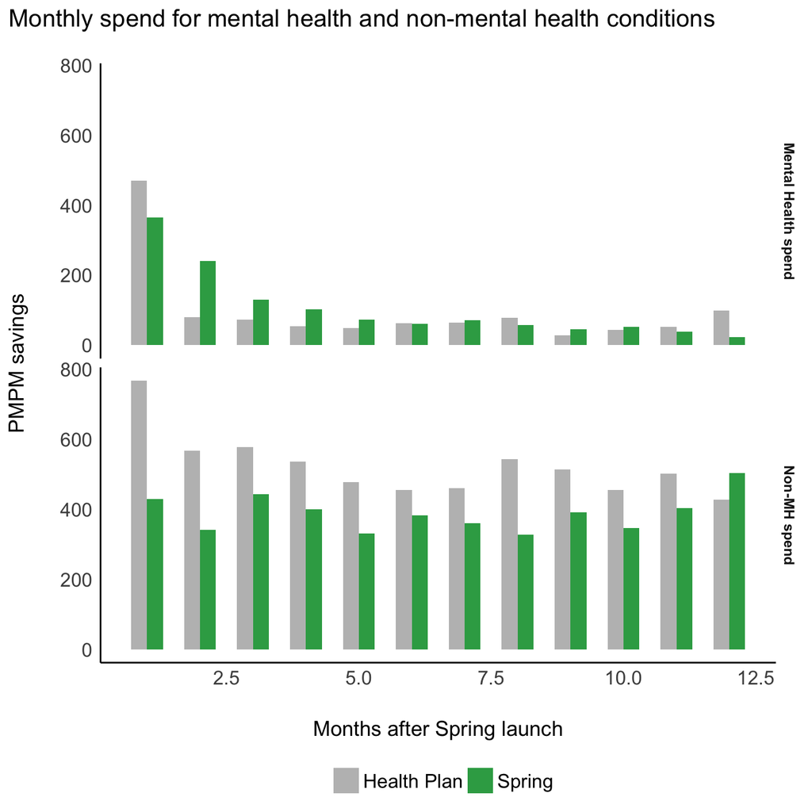

```r
# MH vs non-MH
df_monthly_spend %>%
  group_by(spring_dummy, months, mh_spend) %>%
  summarize(estimate = sum(estimate, na.rm=T)) %>%
  # Plot
  ggplot(., aes(x=months, y=estimate, group = spring_dummy, fill = spring_dummy)) +
  geom_bar(stat = "identity", width = 0.6, position=position_dodge()) +
  scale_fill_manual(values = rev(cc_colors)) +
  #geom_text(aes(x=total, y=chronic_condition, label = round(total, 0), fill = NULL, hjust = ifelse(total < 0, 1.1, -0.4)), colour = "#8e8e8e", size = 3, data = df_labels) +
  #expand_limits(x=c(0, 1.1*max(df_labels$total))) +
  theme_modern() +
  facet_grid(rows=vars(mh_spend), scales = "fixed") +
  theme(legend.position = "bottom") +
  labs(
    title = "Monthly spend for mental health and non-mental health conditions",
    x = "Months after Spring launch",
    y = "PMPM savings",
    fill = " "
  )
```

# 5 ROI

## 5.1 Billing data

```r
# direct bill

## all direct bill appts
billing_appts <- readRDS('~/Library/CloudStorage/GoogleDrive-mhawrilenko@springhealth.com/Shared drives/ROI - Direct bill/HEOR clean/billing data.Rdata')

# Loop stuff
spring_fees <- list()
prop_matched <- vector()
for (i in 1:length(customer_name)) {

  ## Get covered life IDs for members in the study
spring_match_to_elig <- import(paste0(Sys.getenv("claims_folder_path"), "data/", customer_name[i], "/data_to_sba/", customer_name[i], "_", "eligibility_cls.csv")) %>%
  rename(any_of(c(
    carrier_member_id = "member_key",
    carrier_member_id = "indv_id",
    carrier_member_id = "individual_id"
  ))) %>%
  mutate(carrier_member_id = as.character(carrier_member_id)) %>%
  select(carrier_member_id, covered_life_id)


## Need members in the study
study_members <- df_matched %>%
  distinct(carrier_member_id, spring_dummy) %>%
  left_join(spring_match_to_elig)


## Match study members to their appts
apps_query <- "SELECT appointment_id, covered_life_id
               FROM base_appointments
               WHERE UPPER(customer_name) like ?"


apps <- dbGetQuery(con = snowflake_conn("base_layer"), apps_query, params = list(paste0('%', str_to_upper(customer_name[i]), '%'))) %>%
  clean_names()


## Calculate direct bill amounts by group
spring_start_date <- df_matched %>%
  ungroup() %>%
  filter(str_like(customer_name, paste0('%', .env$customer_name[i], '%'), ignore_case = TRUE)) %>%
  distinct(spring_start_date) %>%
  pull(spring_start_date)

spring_end_date <- df_matched %>%
  ungroup() %>%
  filter(str_like(customer_name, paste0('%', .env$customer_name[i], '%'), ignore_case = TRUE)) %>%
  distinct(spring_end_date) %>%
  pull(spring_end_date)

direct_bill <- billing_appts %>%
  filter(str_like(customer_name, paste0('%', .env$customer_name[i], '%'), ignore_case = TRUE)) %>% #.env$customer_name
  filter(month_of_service <= spring_end_date) %>%
  left_join(apps) %>% # get covered life id
  inner_join(study_members) %>% # only individuals included in the study
  ## sometimes an individual has multiple carrier member IDs. DOn't want duplicate billing.
  ## so group by appointment_id and take first carrier_member_id
  group_by(appointment_id) %>%
  filter(carrier_member_id == first(carrier_member_id) | is.na(carrier_member_id)) %>% # address billing data that gets duped
  ungroup() %>%
  summarize(amount = sum(total_billed, na.rm=T)) %>%
  pull(amount)


billing_all <- import(paste0(Sys.getenv("claims_folder_path"), "data/", customer_name[i], "/", customer_name[i], "_", "billing.xlsx")) %>%
  clean_names()

bundle_fee <- billing_all %>%
  filter(str_like(account, paste0('%', "bundle", '%'), ignore_case = TRUE)) %>%
  summarize(bundle_fee = sum(amount, na.rm=T)) %>%
  pull(bundle_fee)

platform_fee <- billing_all %>%
  filter(str_like(account, paste0('%', "platform", '%'), ignore_case = TRUE)) %>%
  summarize(platform_fee = sum(amount, na.rm=T)) %>%
  pull(platform_fee)

billed_to_health_plan <- readRDS(paste0(Sys.getenv("claims_folder_path"), "data/round_2_analysis/intermediate_data/", customer_name[i], "_spring_med_claims.Rdata")) %>%
  filter(month_year <= spring_end_date) %>%
  mutate(carrier_member_id = as.character(carrier_member_id)) %>%
  inner_join(study_members) %>%
  ungroup() %>%
  summarize(billed_to_health_plan = sum(allowed_amt, na.rm=T)) %>%
  pull(billed_to_health_plan)


## Get number of eligible employees on the health plan in the date range
elig <- readRDS(file = paste0(Sys.getenv("claims_folder_path"), "/data/round_2_analysis/intermediate_data/", customer_name[i], "_carrier_elig.Rdata")) %>%
  filter(month_year >= spring_start_date) %>%
  filter(month_year <= spring_end_date) %>%
  filter(employee_flag == "yes")

## Get total employees
qry <- "SELECT DISTINCT a.customer_name, a.customer_id, id, dependent, b.created_at
                  FROM ds_trunk.base_layer.base_customers AS a
                  LEFT JOIN stitch_new.rotom_prod_replica.covered_lives AS b
                  ON a.customer_id = b.customer_id
                  WHERE UPPER(a.customer_name) LIKE ?
                  AND dependent = 'FALSE'
                  AND DATE(b.created_at) <= date(?)"

cl <- dbGetQuery(con = snowflake_conn("rotom"), qry, params = list(paste0('%', str_to_upper(customer_name[i]), '%'), spring_end_date)) %>%
  clean_names()

prop_on_health_plan <- n_distinct(elig$carrier_member_id) / n_distinct(cl$id)

cust_funnel <- data_funnel %>%
  filter(customer_name == .env$customer_name[i])
prop_matched <- pull(cust_funnel[7,4] / cust_funnel[1,4])

# Compile all fees
spring_fees[[i]] <- data.frame(
  fee_type = c("Bundle", "Platform", "Direct bill", "Billed to Health Plan")
) %>%
  mutate(
    customer_name = customer_name[i],
    prop_on_health_plan = prop_on_health_plan,
    prop_matched = prop_matched,
    Amount = case_when(
      fee_type == "Bundle" ~ bundle_fee * prop_on_health_plan * prop_matched,
      fee_type == "Platform" ~ platform_fee * prop_on_health_plan * prop_matched,
      fee_type == "Direct bill" ~ direct_bill,
      fee_type == "Billed to Health Plan" ~ billed_to_health_plan
    )
)
}
spring_fees <- spring_fees %>% bind_rows()

spring_fees %>%
  group_by(customer_name) %>%
  summarize(amount = sum(Amount, na.rm=T))
```

```
## # A tibble: 5 × 2
##   customer_name   amount
##   <chr>            <dbl>
## 1 Docusign       197811.
## 2 Hearst         652430.
## 3 Pepsi         2214623.
## 4 Tegna          509453.
## 5 Wellstar      1058456.
```

```r
total_invoiced <- spring_fees %>%
  summarize(amount = sum(Amount, na.rm=T)) %>%
  pull(amount)
```

## 5.2 Calculate ROI

```r
df_roi <- df_matched %>%
  filter(spring_dummy == "Spring") %>%
  filter(month_year == first_spring_tx_date) %>%
  mutate(months_treated = interval(first_spring_tx_date, spring_end_date) %/% months(1) + 1) %>%
  group_by(months_treated) %>%
  summarize(n = n_distinct(carrier_member_id)) %>%
  mutate(
    member_months_treated = n*months_treated,
    month_roi_gross = n*months_treated*summary(m1_gross_yes_match)$coefficients["spring_dummySpring:phasepost_tx", 1])
mean_months_treated <- sum(df_roi$member_months_treated)/sum(df_roi$n)


# Calculate gross savings %
deltamethod(m1_gross_yes_match, "0 = (6.5*b8) / ((12-6.5)*df_plot$estimate[1] + 6.5*(df_plot$estimate[2]))")
```

```
##
##                                                                       Term
##  0 = (6.5*b8) / ((12-6.5)*df_plot$estimate[1] + 6.5*(df_plot$estimate[2]))
##  Estimate Std. Error    z Pr(>|z|) 2.5 % 97.5 %
##     0.297     0.0251 11.8   <0.001 0.248  0.347
##
## Columns: term, estimate, std.error, statistic, p.value, conf.low, conf.high
```

```r
# Calculate PPPY
deltamethod(m1_gross_yes_match, "0 = -1 * b8 * mean_months_treated")
```

```
##
##                               Term Estimate Std. Error     z Pr(>|z|) 2.5 %
##  0 = -1 * b8 * mean_months_treated    -2101        178 -11.8   <0.001 -2449
##  97.5 %
##   -1753
##
## Columns: term, estimate, std.error, statistic, p.value, conf.low, conf.high
```

```r
# Calculate ROI multiple
deltamethod(m1_gross_yes_match, "0 = (-1*b8*(sum(df_roi$months_treated*df_roi$n)))/total_invoiced")
```

```
##
##                                                              Term Estimate
##  0 = (-1*b8*(sum(df_roi$months_treated*df_roi$n)))/total_invoiced    -1.65
##  Std. Error     z Pr(>|z|) 2.5 % 97.5 %
##       0.139 -11.8   <0.001 -1.92  -1.38
##
## Columns: term, estimate, std.error, statistic, p.value, conf.low, conf.high
```